# Proteomics Filtering Pipeline

Lung Tumour — Satpathy 2021

Yashna Paul

2026-04-13

# 1 Setup

> **Aim:** Load required packages and set seed for reproducibility.

```r
suppressPackageStartupMessages({
  library(tidyverse)
  library(matrixStats)
  library(knitr)
  library(kableExtra)
})

set.seed(123)
```

# 2 Load Data

```r
data_dir <- "/cellfile/DATASETS/Human/Multi-tissue/Multi_omics/Public/LamanTripEtAl2025_processedMatrices/"

prot_data <- read_csv(paste0(data_dir, "Data/lung_satpathy2021_prot_tumor.csv"), show_col_types = FALSE)
mrna_data <- read_csv(paste0(data_dir,"Data/lung_satpathy2021_rna_tumor_idfix_subsetted.csv"), show_col_types = FALSE)

expr <- prot_data %>%
  dplyr::select(where(is.numeric)) %>%
  as.matrix()
rownames(expr) <- prot_data$symbol

mrna <- mrna_data %>%
  dplyr::select(where(is.numeric)) %>%
  as.matrix()
rownames(mrna) <- mrna_data$symbol

cat("Initial proteins:", nrow(expr), "\n")
```

```
## Initial proteins: 11111
```

```r
cat("Initial mRNA genes:", nrow(mrna), "\n")
```

```
## Initial mRNA genes: 10938
```

```r
cat("Protein samples:", ncol(expr), "\n")
```

```
## Protein samples: 108
```

```r
cat("mRNA samples:", ncol(mrna), "\n")
```

```
## mRNA samples: 108
```

# 3 mRNA–Protein Correlation (Before Filtering)

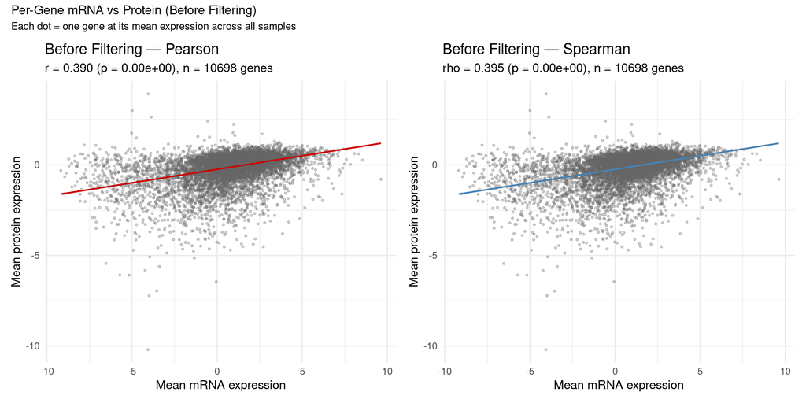

```r
common_genes_raw   <- intersect(rownames(expr), rownames(mrna))
common_samples_raw <- intersect(colnames(expr), colnames(mrna))

prot_common_raw <- expr[common_genes_raw, common_samples_raw, drop = FALSE]
mrna_common_raw <- mrna[common_genes_raw, common_samples_raw, drop = FALSE]

gene_means_before <- tibble(
  gene         = common_genes_raw,
  protein_mean = rowMeans(prot_common_raw, na.rm = TRUE),
  mrna_mean    = rowMeans(mrna_common_raw, na.rm = TRUE)
) %>%
  filter(is.finite(protein_mean) & is.finite(mrna_mean))

cor_pearson_before  <- cor.test(gene_means_before$mrna_mean,
                                gene_means_before$protein_mean,
                                method = "pearson")
cor_spearman_before <- cor.test(gene_means_before$mrna_mean,
                                gene_means_before$protein_mean,
                                method = "spearman")

p_bef_pear <- ggplot(gene_means_before, aes(x = mrna_mean, y = protein_mean)) +
  geom_point(alpha = 0.3, size = 0.8, colour = "grey40") +
  geom_smooth(method = "lm", se = FALSE, colour = "red3", linewidth = 0.8) +
  labs(x = "Mean mRNA expression", y = "Mean protein expression",
       title = "Before Filtering — Pearson",
       subtitle = sprintf("r = %.3f (p = %.2e), n = %d genes",
                          cor_pearson_before$estimate,
                          cor_pearson_before$p.value,
                          nrow(gene_means_before))) +
  theme_minimal(base_size = 13)

p_bef_spear <- ggplot(gene_means_before, aes(x = mrna_mean, y = protein_mean)) +
  geom_point(alpha = 0.3, size = 0.8, colour = "grey40") +
  geom_smooth(method = "lm", se = FALSE, colour = "steelblue", linewidth = 0.8) +
  labs(x = "Mean mRNA expression", y = "Mean protein expression",
       title = "Before Filtering — Spearman",
       subtitle = sprintf("rho = %.3f (p = %.2e), n = %d genes",
                          cor_spearman_before$estimate,
                          cor_spearman_before$p.value,
                          nrow(gene_means_before))) +
  theme_minimal(base_size = 13)

library(patchwork)
p_bef_pear + p_bef_spear +
  plot_annotation(title = "Per-Gene mRNA vs Protein (Before Filtering)",
                  subtitle = "Each dot = one gene at its mean expression across all samples")
```

## 3.1 Per-Gene Correlation Across Samples (Before Filtering)

> **Aim:** For each gene, compute the Spearman correlation between its protein and mRNA values across all samples. This gives one ρ per gene and answers: “For this specific gene, do samples with higher mRNA also have higher protein?” This is complementary to the mean-expression plot above — that one asks whether highly-transcribed genes tend to have high protein (across genes), while this one asks whether within-gene variation tracks between mRNA and protein (across samples). Computing this before filtering provides a baseline to compare against the post-filtering histogram.

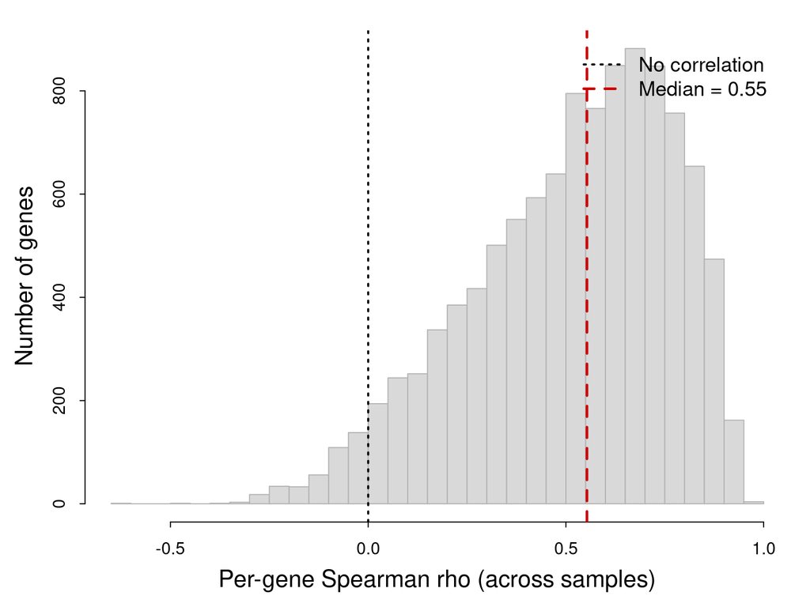

```r
gene_cor_before <- vapply(seq_len(nrow(prot_common_raw)), function(i) {
  cor(prot_common_raw[i, ], mrna_common_raw[i, ],
      method = "spearman", use = "pairwise.complete.obs")
}, numeric(1))
names(gene_cor_before) <- rownames(prot_common_raw)
gene_cor_before <- gene_cor_before[is.finite(gene_cor_before)]
med_cor_before  <- median(gene_cor_before, na.rm = TRUE)

par(mar = c(4.2, 4.2, 1.5, 1.0), mgp = c(2.4, 0.8, 0), tcl = -0.25,
    cex.lab = 1.4, cex.axis = 1.0, bty = "l")
hist(gene_cor_before, breaks = 50, col = "grey85", border = "grey70",
     main = "", xlab = "Per-gene Spearman rho (across samples)",
     ylab = "Number of genes")
abline(v = 0, col = "black", lwd = 2, lty = 3)
abline(v = med_cor_before, col = "red3", lwd = 2.5, lty = 2)
legend("topright",
       legend = c("No correlation", sprintf("Median = %.2f", med_cor_before)),
       col = c("black", "red3"), lwd = c(2, 2.5), lty = c(3, 2),
       bty = "n", cex = 1.2, inset = 0.02)
```

```r
cat(sprintf("Before filtering: %d genes, median Spearman rho = %.3f\n",
            length(gene_cor_before), med_cor_before))
```

```
## Before filtering: 10698 genes, median Spearman rho = 0.553
```

# 4 Filtering Pipeline

## 4.1 Step 1: Presence Filter

> **What it does:** Computes a global expression threshold (5th percentile of all protein values). For each protein, calculates the fraction of samples where expression exceeds this threshold. Proteins detected in fewer than 95% of samples are removed.

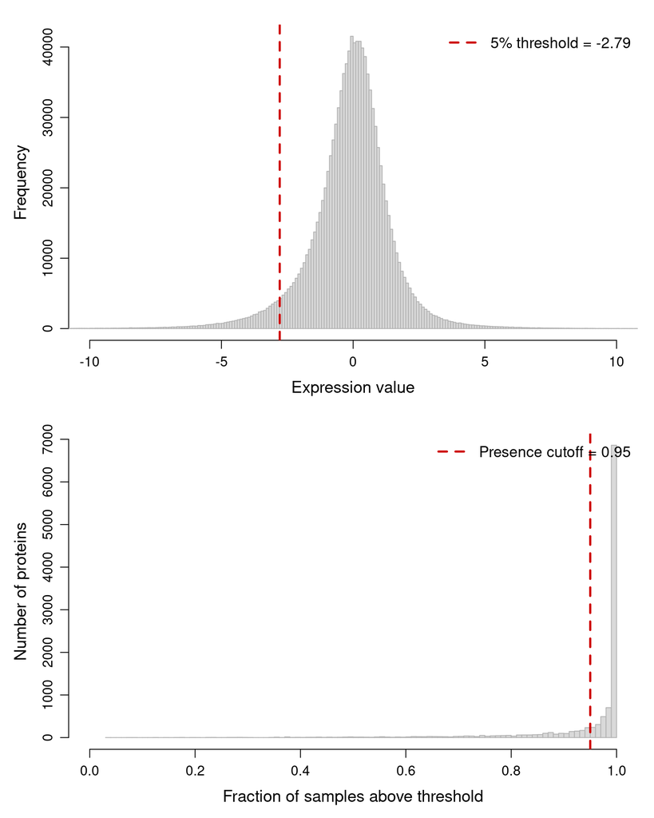

```r
expr_q05 <- quantile(expr, 0.05, na.rm = TRUE)
presence <- rowMeans(expr > expr_q05, na.rm = TRUE)

par(mfrow = c(2, 1), mar = c(4.2, 4.2, 1.5, 1.0), mgp = c(2.4, 0.8, 0),
    cex.lab = 1.2, cex.axis = 1.0, bty = "l")

hist(as.vector(expr), breaks = 500, xlim = c(-10, 10),
     col = "grey85", border = "grey70",
     main = "", xlab = "Expression value", ylab = "Frequency")
abline(v = expr_q05, col = "red3", lwd = 2.5, lty = 2)
legend("topright", legend = sprintf("5%% threshold = %.2f", expr_q05),
       col = "red3", lwd = 2.5, lty = 2, bty = "n", cex = 1.1)

hist(presence, breaks = 100, xlim = c(0, 1),
     col = "grey85", border = "grey70",
     main = "", xlab = "Fraction of samples above threshold",
     ylab = "Number of proteins")
abline(v = 0.95, col = "red3", lwd = 2.5, lty = 2)
legend("topright", legend = "Presence cutoff = 0.95",
       col = "red3", lwd = 2.5, lty = 2, bty = "n", cex = 1.1)
```

```r
par(mfrow = c(1, 1))

expr_filt <- expr[presence >= 0.95, , drop = FALSE]
n_after_presence <- nrow(expr_filt)
cat(sprintf("After presence filter: %d → %d proteins\n", nrow(expr), n_after_presence))
```

```
## After presence filter: 11111 → 8611 proteins
```

## 4.2 Step 2: IQR Filter (Protein)

> **What it does:** Computes the interquartile range (IQR) of each protein across samples and removes the bottom 10%.

> **Why:** Proteins with near-zero IQR have essentially constant expression and carry no discriminative signal for downstream modelling. IQR is preferred over standard deviation because it is robust to outliers — a single extreme sample will not inflate the spread estimate and rescue a genuinely flat protein.

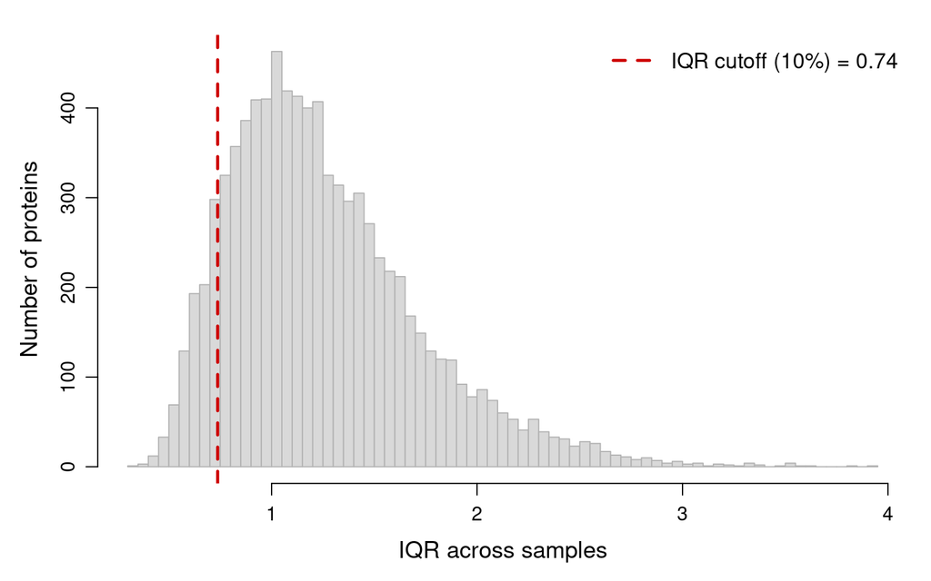

```r
iqr_vals <- apply(expr_filt, 1, IQR, na.rm = TRUE)
iqr_cut  <- quantile(iqr_vals, 0.10, na.rm = TRUE)

par(mar = c(4.2, 4.2, 1.5, 1.0), mgp = c(2.4, 0.8, 0),
    cex.lab = 1.2, cex.axis = 1.0, bty = "l")
hist(iqr_vals, breaks = 100,
     col = "grey85", border = "grey70",
     main = "", xlab = "IQR across samples", ylab = "Number of proteins")
abline(v = iqr_cut, col = "red3", lwd = 2.5, lty = 2)
legend("topright", legend = sprintf("IQR cutoff (10%%) = %.2f", iqr_cut),
       col = "red3", lwd = 2.5, lty = 2, bty = "n", cex = 1.1)
```

```r
n_before <- nrow(expr_filt)
expr_filt <- expr_filt[iqr_vals > iqr_cut, , drop = FALSE]
n_after_iqr <- nrow(expr_filt)
cat(sprintf("After IQR filter: %d → %d proteins\n", n_before, n_after_iqr))
```

```
## After IQR filter: 8611 → 7749 proteins
```

## 4.3 Step 3: MAD Filter (Protein)

> **What it does:** Computes the median absolute deviation (MAD) of each protein across samples and removes the bottom 5%.

> **Why:** This is a second robustness layer. It catches proteins that passed the IQR filter but still have very low dispersion around the median — for instance, proteins with a tight IQR but a single extreme outlier inflating the range. This conservative cleanup removes very few additional proteins.

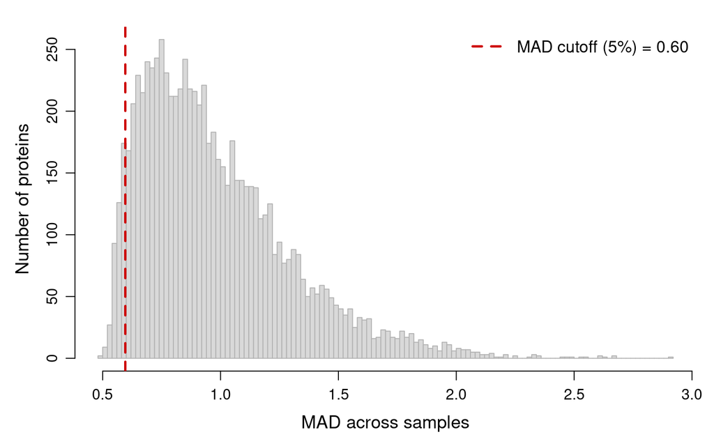

```r
mad_vals <- rowMads(expr_filt, na.rm = TRUE)
mad_cut  <- quantile(mad_vals, 0.05, na.rm = TRUE)

par(mar = c(4.2, 4.2, 1.5, 1.0), mgp = c(2.4, 0.8, 0),
    cex.lab = 1.2, cex.axis = 1.0, bty = "l")
hist(mad_vals, breaks = 100,
     col = "grey85", border = "grey70",
     main = "", xlab = "MAD across samples", ylab = "Number of proteins")
abline(v = mad_cut, col = "red3", lwd = 2.5, lty = 2)
legend("topright", legend = sprintf("MAD cutoff (5%%) = %.2f", mad_cut),
       col = "red3", lwd = 2.5, lty = 2, bty = "n", cex = 1.1)
```

```r
n_before <- nrow(expr_filt)
expr_filt <- expr_filt[mad_vals > mad_cut, , drop = FALSE]
n_after_mad <- nrow(expr_filt)
cat(sprintf("After MAD filter: %d → %d proteins\n", n_before, n_after_mad))
```

```
## After MAD filter: 7749 → 7360 proteins
```

## 4.4 Step 4: IQR Filter (mRNA)

> **What it does:** Computes the IQR of each mRNA feature across samples and removes the bottom 5%.

> **Why:** Ensures that mRNA features used in downstream modelling (both for OLS residualisation and as LASSO predictors in Model B) have sufficient cross-sample variability. A more lenient cutoff (5% vs 10% for proteins) is used because mRNA data typically has fewer near-zero-variance features.

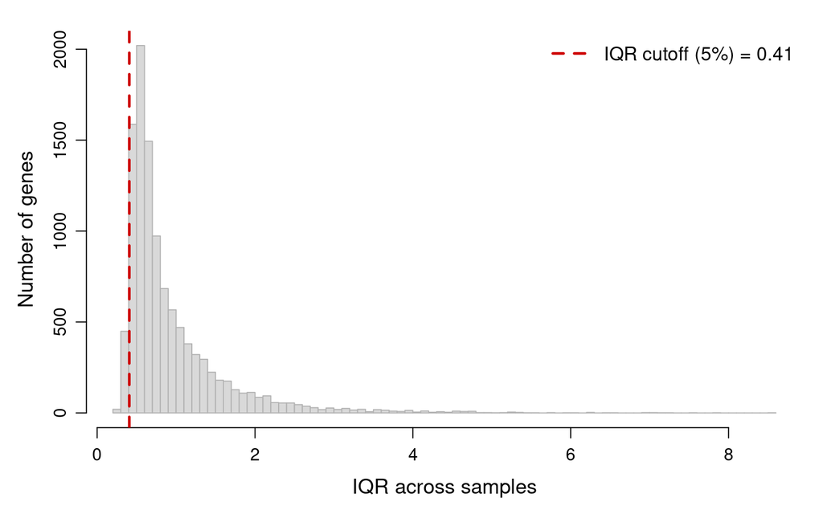

```r
mrna_iqr     <- apply(mrna, 1, IQR, na.rm = TRUE)
iqr_cut_mrna <- quantile(mrna_iqr, 0.05, na.rm = TRUE)

par(mar = c(4.2, 4.2, 1.5, 1.0), mgp = c(2.4, 0.8, 0),
    cex.lab = 1.2, cex.axis = 1.0, bty = "l")
hist(mrna_iqr, breaks = 100,
     col = "grey85", border = "grey70",
     main = "", xlab = "IQR across samples", ylab = "Number of genes")
abline(v = iqr_cut_mrna, col = "red3", lwd = 2.5, lty = 2)
legend("topright", legend = sprintf("IQR cutoff (5%%) = %.2f", iqr_cut_mrna),
       col = "red3", lwd = 2.5, lty = 2, bty = "n", cex = 1.1)
```

```r
mrna_filt <- mrna[mrna_iqr > iqr_cut_mrna, , drop = FALSE]
n_after_mrna_iqr <- nrow(mrna_filt)
cat(sprintf("After mRNA IQR filter: %d → %d genes\n", nrow(mrna), n_after_mrna_iqr))
```

```
## After mRNA IQR filter: 10938 → 10391 genes
```

## 4.5 Step 5: Match Proteins with mRNA

> **What it does:** Intersects the gene symbols and sample IDs between the filtered protein and mRNA matrices so that both matrices have identical rows (genes) and columns (samples).

> **Why:** Downstream analyses (OLS residualisation, LASSO modelling) require paired protein–mRNA measurements for each gene in each sample. Any gene or sample present in only one matrix must be dropped.

```r
common_genes   <- intersect(rownames(expr_filt), rownames(mrna_filt))
expr_filt      <- expr_filt[common_genes, , drop = FALSE]
mrna_filt      <- mrna_filt[common_genes, , drop = FALSE]

common_samples <- intersect(colnames(expr_filt), colnames(mrna_filt))
expr_filt      <- expr_filt[, common_samples, drop = FALSE]
mrna_filt      <- mrna_filt[, common_samples, drop = FALSE]

cat(sprintf("After matching: %d genes × %d samples\n",
            nrow(expr_filt), ncol(expr_filt)))
```

```
## After matching: 6827 genes × 108 samples
```

# 5 mRNA–Protein Correlation (After Filtering)

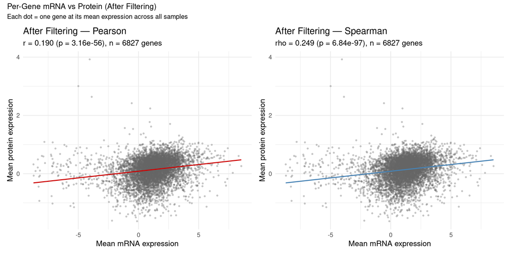

```r
gene_means_after <- tibble(
  gene         = rownames(expr_filt),
  protein_mean = rowMeans(expr_filt, na.rm = TRUE),
  mrna_mean    = rowMeans(mrna_filt, na.rm = TRUE)
) %>%
  filter(is.finite(protein_mean) & is.finite(mrna_mean))

cor_pearson_after  <- cor.test(gene_means_after$mrna_mean,
                               gene_means_after$protein_mean,
                               method = "pearson")
cor_spearman_after <- cor.test(gene_means_after$mrna_mean,
                               gene_means_after$protein_mean,
                               method = "spearman")

p_aft_pear <- ggplot(gene_means_after, aes(x = mrna_mean, y = protein_mean)) +
  geom_point(alpha = 0.3, size = 0.8, colour = "grey40") +
  geom_smooth(method = "lm", se = FALSE, colour = "red3", linewidth = 0.8) +
  labs(x = "Mean mRNA expression", y = "Mean protein expression",
       title = "After Filtering — Pearson",
       subtitle = sprintf("r = %.3f (p = %.2e), n = %d genes",
                          cor_pearson_after$estimate,
                          cor_pearson_after$p.value,
                          nrow(gene_means_after))) +
  theme_minimal(base_size = 13)

p_aft_spear <- ggplot(gene_means_after, aes(x = mrna_mean, y = protein_mean)) +
  geom_point(alpha = 0.3, size = 0.8, colour = "grey40") +
  geom_smooth(method = "lm", se = FALSE, colour = "steelblue", linewidth = 0.8) +
  labs(x = "Mean mRNA expression", y = "Mean protein expression",
       title = "After Filtering — Spearman",
       subtitle = sprintf("rho = %.3f (p = %.2e), n = %d genes",
                          cor_spearman_after$estimate,
                          cor_spearman_after$p.value,
                          nrow(gene_means_after))) +
  theme_minimal(base_size = 13)

p_aft_pear + p_aft_spear +
  plot_annotation(title = "Per-Gene mRNA vs Protein (After Filtering)",
                  subtitle = "Each dot = one gene at its mean expression across all samples")
```

# 6 Protein–mRNA Correlation QC (Per-Gene, Across Samples)

> **Aim:** For each gene, compute the Spearman correlation between its protein and mRNA values across all samples. This gives one ρ per gene and answers: “For this specific gene, do samples with higher mRNA also have higher protein?” The distribution of these per-gene correlations characterises the overall strength of transcriptional control in this dataset. The median ρ is a key QC metric — it should be moderately positive (typically 0.3–0.5 for TMT proteomics).

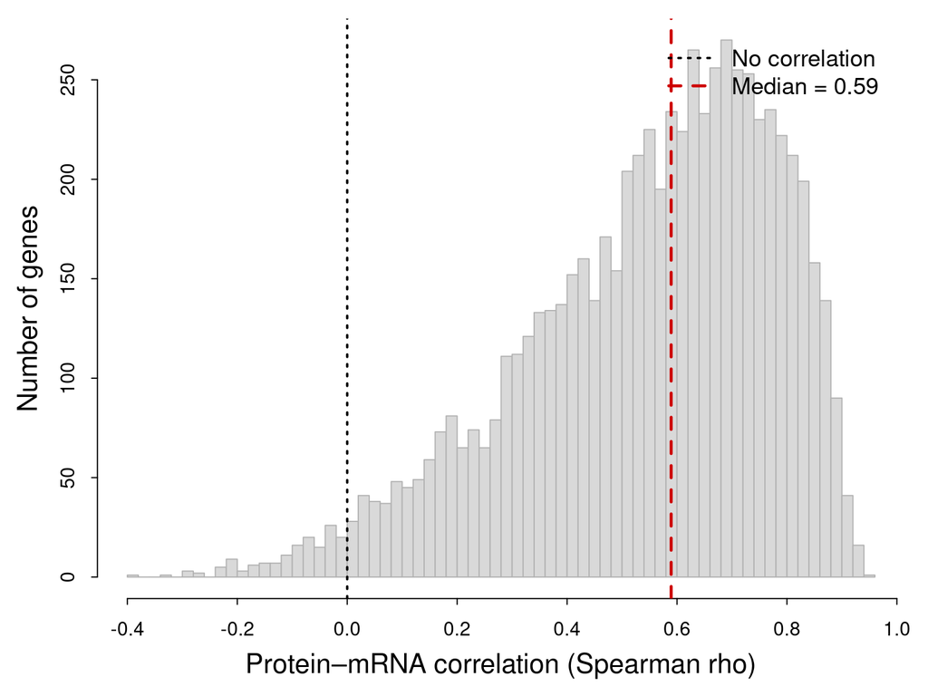

```r
stopifnot(identical(rownames(expr_filt), rownames(mrna_filt)))

gene_cor <- vapply(seq_len(nrow(expr_filt)), function(i) {
  cor(expr_filt[i, ], mrna_filt[i, ], method = "spearman",
      use = "pairwise.complete.obs")
}, numeric(1))
names(gene_cor) <- rownames(expr_filt)

gene_cor <- gene_cor[is.finite(gene_cor)]
med_cor  <- median(gene_cor, na.rm = TRUE)

par(mar = c(4.2, 4.2, 0.8, 1.0), mgp = c(2.4, 0.8, 0), tcl = -0.25,
    cex.lab = 1.4, cex.axis = 1.0, bty = "l")
hist(gene_cor, breaks = 50, col = "grey85", border = "grey70",
     main = "", xlab = "Protein–mRNA correlation (Spearman rho)",
     ylab = "Number of genes")
abline(v = 0, col = "black", lwd = 2, lty = 3)
abline(v = med_cor, col = "red3", lwd = 2.5, lty = 2)
legend("topright",
       legend = c("No correlation", sprintf("Median = %.2f", med_cor)),
       col = c("black", "red3"), lwd = c(2, 2.5), lty = c(3, 2),
       bty = "n", cex = 1.2, inset = 0.02)
```

## 6.1 Diagnosing the Correlation Drop

> **Aim:** The mean-expression Spearman correlation drops from ~0.39 (before filtering, ~10,700 genes) to ~0.24 (after filtering, ~6,800 genes). We investigate whether the presence filter selectively removes genes with specific expression or correlation properties.

### 6.1.1 Classify Genes: Kept vs Filtered Out

```r
kept_genes     <- rownames(expr_filt)
all_genes_raw  <- rownames(prot_common_raw)
filtered_genes <- setdiff(all_genes_raw, kept_genes)

cat(sprintf("Total genes (before): %d\n", length(all_genes_raw)))
```

```
## Total genes (before): 10698
```

```r
cat(sprintf("Kept (after filtering): %d\n", length(kept_genes)))
```

```
## Kept (after filtering): 6827
```

```r
cat(sprintf("Filtered out: %d\n", length(filtered_genes)))
```

```
## Filtered out: 3871
```

```r
# ── Compute mean expression per gene for classification ──
density_df <- tibble(
  gene         = all_genes_raw,
  protein_mean = rowMeans(prot_common_raw, na.rm = TRUE),
  mrna_mean    = rowMeans(mrna_common_raw, na.rm = TRUE),
  group        = if_else(gene %in% kept_genes, "Kept", "Filtered out")
) %>%
  filter(is.finite(protein_mean) & is.finite(mrna_mean)) %>%
  mutate(group = factor(group, levels = c("Kept", "Filtered out")))
```

### 6.1.2 Density Plot 1: Whole Dataset — mRNA vs Protein Expression

> **What this shows:** The distribution of mean mRNA and mean protein expression across ALL genes before any filtering. Overlaying both on the same plot reveals whether the two data types have similar dynamic ranges and whether there is a subpopulation of genes with divergent mRNA and protein levels.

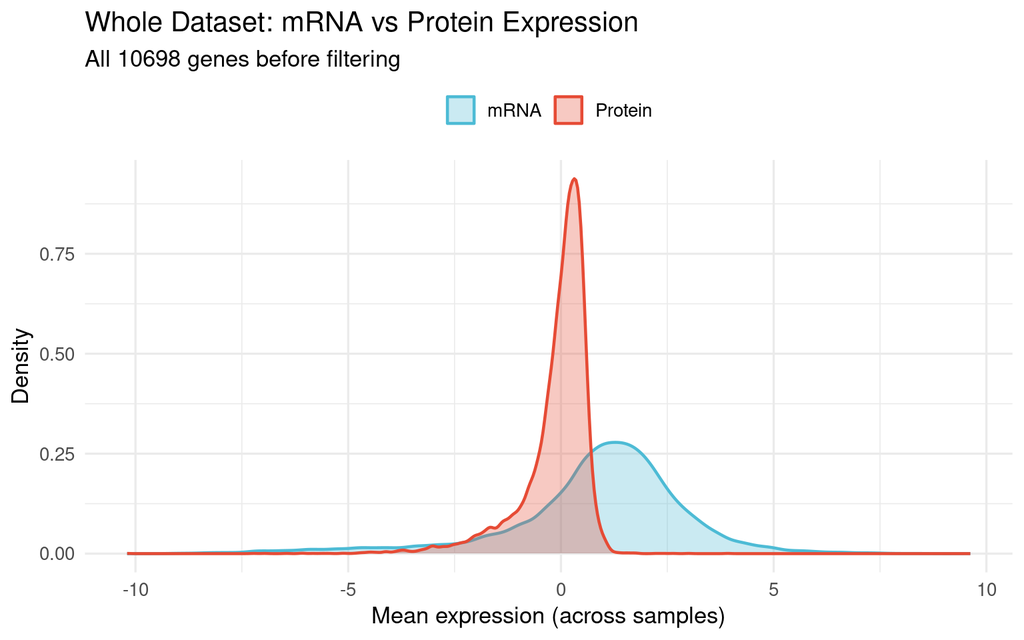

```r
density_all <- density_df %>%
  dplyr::select(gene, protein_mean, mrna_mean) %>%
  pivot_longer(cols = c(protein_mean, mrna_mean),
               names_to = "data_type", values_to = "mean_expr") %>%
  mutate(data_type = recode(data_type,
                            protein_mean = "Protein",
                            mrna_mean    = "mRNA"))

ggplot(density_all, aes(x = mean_expr, fill = data_type, colour = data_type)) +
  geom_density(alpha = 0.3, linewidth = 0.8) +
  scale_fill_manual(values = c("Protein" = "#E64B35", "mRNA" = "#4DBBD5")) +
  scale_colour_manual(values = c("Protein" = "#E64B35", "mRNA" = "#4DBBD5")) +
  labs(x = "Mean expression (across samples)",
       y = "Density",
       fill = NULL, colour = NULL,
       title = "Whole Dataset: mRNA vs Protein Expression",
       subtitle = sprintf("All %d genes before filtering", nrow(density_df))) +
  theme_minimal(base_size = 13) +
  theme(legend.position = "top")
```

### 6.1.3 Density Plot 2: Filtered-Out Genes — mRNA vs Protein Expression

> **What this shows:** The expression profile of the ~4,000 genes removed by the filtering pipeline. The key question is the relative position of the mRNA and protein densities. If both shift left equally (low mRNA, low protein), these are simply lowly-expressed genes. If protein shifts left but mRNA stays central or shifts right (high mRNA, low protein), these genes are candidates for post-transcriptional suppression — and the filter is removing exactly the genes we might care about most.

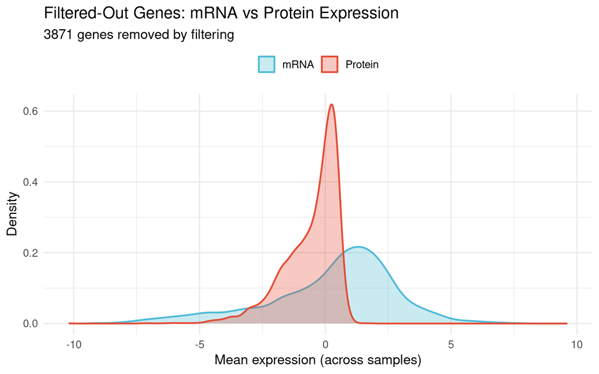

```r
density_filt_out <- density_df %>%
  filter(group == "Filtered out") %>%
  dplyr::select(gene, protein_mean, mrna_mean) %>%
  pivot_longer(cols = c(protein_mean, mrna_mean),
               names_to = "data_type", values_to = "mean_expr") %>%
  mutate(data_type = recode(data_type,
                            protein_mean = "Protein",
                            mrna_mean    = "mRNA"))

ggplot(density_filt_out, aes(x = mean_expr, fill = data_type, colour = data_type)) +
  geom_density(alpha = 0.3, linewidth = 0.8) +
  scale_fill_manual(values = c("Protein" = "#E64B35", "mRNA" = "#4DBBD5")) +
  scale_colour_manual(values = c("Protein" = "#E64B35", "mRNA" = "#4DBBD5")) +
  labs(x = "Mean expression (across samples)",
       y = "Density",
       fill = NULL, colour = NULL,
       title = "Filtered-Out Genes: mRNA vs Protein Expression",
       subtitle = sprintf("%d genes removed by filtering",
                          sum(density_df$group == "Filtered out"))) +
  theme_minimal(base_size = 13) +
  theme(legend.position = "top")
```

### 6.1.4 Density Plot 3: Kept Genes — mRNA vs Protein Expression

> **What this shows:** The expression profile of the ~6,800 genes retained after filtering. Comparing this with the filtered-out plot (above) reveals whether the kept genes have a systematically different mRNA-protein relationship. If the mRNA and protein densities are more overlapping here than in the filtered-out set, the kept genes have tighter transcriptional coupling (mRNA ≈ protein). If the mRNA density is wider or shifted differently, post-transcriptional control plays a different role.

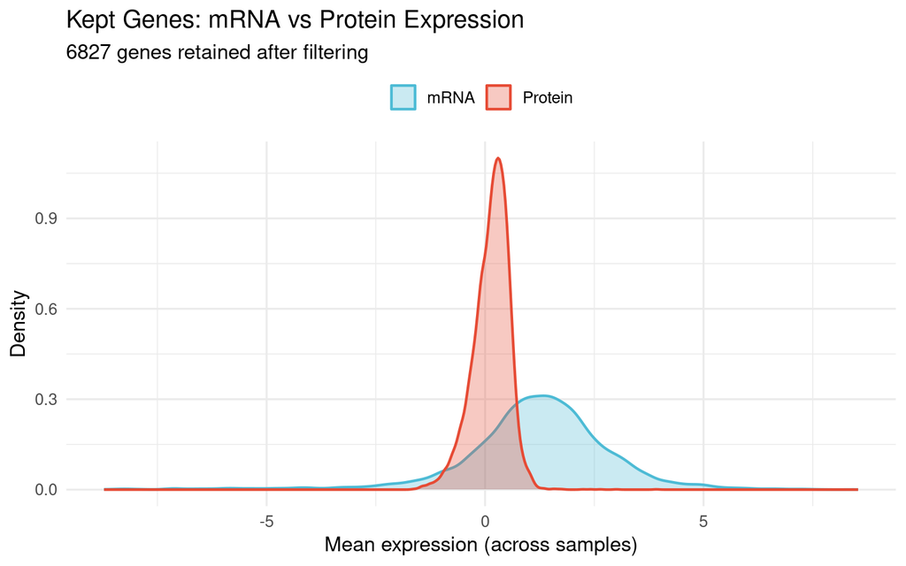

```r
density_kept <- density_df %>%
  filter(group == "Kept") %>%
  dplyr::select(gene, protein_mean, mrna_mean) %>%
  pivot_longer(cols = c(protein_mean, mrna_mean),
               names_to = "data_type", values_to = "mean_expr") %>%
  mutate(data_type = recode(data_type,
                            protein_mean = "Protein",
                            mrna_mean    = "mRNA"))

ggplot(density_kept, aes(x = mean_expr, fill = data_type, colour = data_type)) +
  geom_density(alpha = 0.3, linewidth = 0.8) +
  scale_fill_manual(values = c("Protein" = "#E64B35", "mRNA" = "#4DBBD5")) +
  scale_colour_manual(values = c("Protein" = "#E64B35", "mRNA" = "#4DBBD5")) +
  labs(x = "Mean expression (across samples)",
       y = "Density",
       fill = NULL, colour = NULL,
       title = "Kept Genes: mRNA vs Protein Expression",
       subtitle = sprintf("%d genes retained after filtering",
                          sum(density_df$group == "Kept"))) +
  theme_minimal(base_size = 13) +
  theme(legend.position = "top")
```

### 6.1.5 Per-Gene Spearman Rho: Kept vs Filtered Out

> **What this shows:** Do the filtered-out genes have different mRNA-protein coupling than the kept genes? If filtered-out genes have higher per-gene rho, the filter is removing transcriptionally-controlled genes. If lower, the filtered-out genes are noisy. If the same, the filtering does not selectively act on the strength of within-gene mRNA-protein coupling.

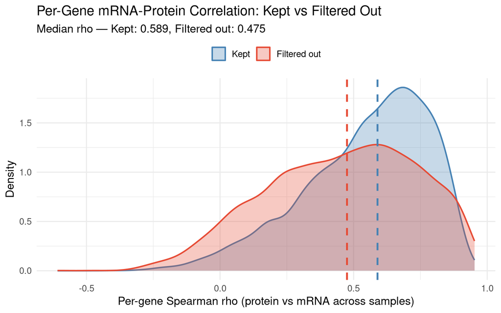

```r
rho_all <- vapply(seq_len(nrow(prot_common_raw)), function(i) {
  cor(prot_common_raw[i, ], mrna_common_raw[i, ],
      method = "spearman", use = "pairwise.complete.obs")
}, numeric(1))
names(rho_all) <- rownames(prot_common_raw)

rho_df <- tibble(
  gene  = names(rho_all),
  rho   = rho_all,
  group = if_else(gene %in% kept_genes, "Kept", "Filtered out")
) %>%
  filter(is.finite(rho)) %>%
  mutate(group = factor(group, levels = c("Kept", "Filtered out")))

med_kept <- median(rho_df$rho[rho_df$group == "Kept"], na.rm = TRUE)
med_filt <- median(rho_df$rho[rho_df$group == "Filtered out"], na.rm = TRUE)

ggplot(rho_df, aes(x = rho, fill = group, colour = group)) +
  geom_density(alpha = 0.3, linewidth = 0.8) +
  geom_vline(xintercept = med_kept, colour = "steelblue",
             linewidth = 1, linetype = "dashed") +
  geom_vline(xintercept = med_filt, colour = "#E64B35",
             linewidth = 1, linetype = "dashed") +
  scale_fill_manual(values = c("Kept" = "steelblue", "Filtered out" = "#E64B35")) +
  scale_colour_manual(values = c("Kept" = "steelblue", "Filtered out" = "#E64B35")) +
  labs(x = "Per-gene Spearman rho (protein vs mRNA across samples)",
       y = "Density",
       fill = NULL, colour = NULL,
       title = "Per-Gene mRNA-Protein Correlation: Kept vs Filtered Out",
       subtitle = sprintf("Median rho — Kept: %.3f, Filtered out: %.3f",
                          med_kept, med_filt)) +
  theme_minimal(base_size = 13) +
  theme(legend.position = "top")
```

```r
wt_rho <- wilcox.test(rho ~ group, data = rho_df)
cat(sprintf("Wilcoxon test (rho: Kept vs Filtered out): p = %.2e\n", wt_rho$p.value))
```

```
## Wilcoxon test (rho: Kept vs Filtered out): p = 9.27e-66
```

### 6.1.6 Summary Table: Kept vs Filtered Out

```r
density_df %>%
  group_by(group) %>%
  summarise(
    n           = n(),
    med_protein = median(protein_mean, na.rm = TRUE),
    med_mrna    = median(mrna_mean, na.rm = TRUE),
    .groups     = "drop"
  ) %>%
  left_join(
    rho_df %>% group_by(group) %>%
      summarise(med_rho = median(rho, na.rm = TRUE), .groups = "drop"),
    by = "group"
  ) %>%
  kable(digits = 3,
        col.names = c("Group", "N genes", "Median protein", "Median mRNA",
                       "Median per-gene rho"),
        caption = "Expression and correlation properties: kept vs filtered-out genes") %>%
  kable_styling(bootstrap_options = c("striped", "hover"), full_width = FALSE)
```

Expression and correlation properties: kept vs filtered-out genes

| Group | N genes | Median protein | Median mRNA | Median per-gene rho |
| --- | --- | --- | --- | --- |
| Kept | 6827 | 0.193 | 1.273 | 0.589 |
| Filtered out | 3871 | -0.224 | 0.799 | 0.475 |

### 6.1.7 Permutation Test: Is the Correlation Drop Real?

> **Aim:** Test whether the drop in mean-expression Spearman correlation (from ~0.39 to ~0.24 after filtering) is explained by having fewer genes, or whether the filter selectively removes genes that anchored the correlation.

> **How it works:** We randomly sample the same number of genes as the post-filter set (n ≈ 6,800) from the full pre-filter gene set (n ≈ 10,700) — ignoring any expression-based criterion — and compute the Spearman correlation of mean mRNA vs mean protein across those randomly chosen genes. This is repeated 1,000 times to build a null distribution. The permutation acts on **gene identity** (which mRNA-protein pairs are included), not on sample labels or expression values.

> If the observed post-filter correlation falls within this null distribution, the drop is a sample-size artefact. If it falls significantly below (left tail), the filter is selectively removing genes that contributed disproportionately to the correlation.

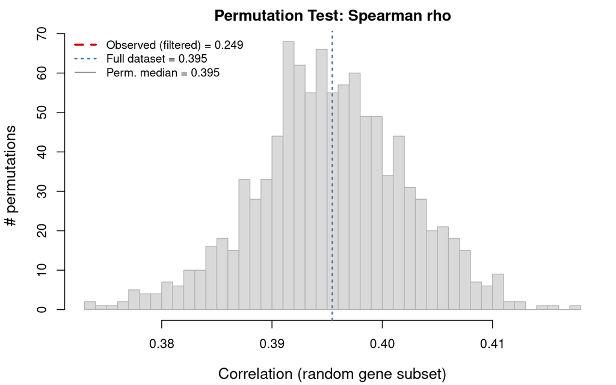

```r
set.seed(42)

n_after <- sum(density_df$group == "Kept")
n_perms <- 1000

perm_cors_spearman <- numeric(n_perms)

for (i in seq_len(n_perms)) {
  idx <- sample(seq_len(nrow(gene_means_before)), size = n_after, replace = FALSE)
  sub <- gene_means_before[idx, ]
  perm_cors_spearman[i] <- cor(sub$mrna_mean, sub$protein_mean, method = "spearman")
}

obs_spearman <- cor_spearman_after$estimate
p_perm       <- mean(perm_cors_spearman <= obs_spearman)

par(mar = c(4.2, 4.2, 2, 1), cex.lab = 1.2, cex.axis = 1.0, bty = "l")
hist(perm_cors_spearman, breaks = 40, col = "grey85", border = "grey70",
     main = "Permutation Test: Spearman rho",
     xlab = "Correlation (random gene subset)",
     ylab = "# permutations")
abline(v = obs_spearman, col = "red3", lwd = 2.5, lty = 2)
abline(v = cor_spearman_before$estimate, col = "steelblue", lwd = 2, lty = 3)
legend("topleft",
       legend = c(sprintf("Observed (filtered) = %.3f", obs_spearman),
                  sprintf("Full dataset = %.3f", cor_spearman_before$estimate),
                  sprintf("Perm. median = %.3f", median(perm_cors_spearman))),
       col = c("red3", "steelblue", "grey50"),
       lwd = c(2.5, 2, 1), lty = c(2, 3, 1),
       bty = "n", cex = 0.9)
```

```r
cat(sprintf("Permutation test (n = %d):\n", n_perms))
```

```
## Permutation test (n = 1000):
```

```r
cat(sprintf("  Observed (filtered): %.3f\n", obs_spearman))
```

```
##   Observed (filtered): 0.249
```

```r
cat(sprintf("  Permutation median:  %.3f\n", median(perm_cors_spearman)))
```

```
##   Permutation median:  0.395
```

```r
cat(sprintf("  p(random <= observed): %.3f\n", p_perm))
```

```
##   p(random <= observed): 0.000
```

```r
if (p_perm < 0.05) {
  cat("> **Interpretation:** The observed post-filter correlation is significantly\n")
  cat("> lower than expected from random subsets of the same size (p < 0.05).\n")
  cat("> The presence filter selectively removes genes that contributed to the\n")
  cat("> mRNA-protein correlation. The density plots above clarify whether\n")
  cat("> those genes had a specific expression profile (e.g., jointly low\n")
  cat("> mRNA and protein anchoring the bottom-left of the scatter).\n")
} else {
  cat("> **Interpretation:** The observed post-filter correlation falls within the\n")
  cat("> range of random subsets (p >= 0.05). The correlation drop is largely\n")
  cat("> explained by having fewer genes, not by biological differences between\n")
  cat("> kept and removed genes.\n")
}
```

> **Interpretation:** The observed post-filter correlation is significantly lower than expected from random subsets of the same size (p < 0.05). The presence filter selectively removes genes that contributed to the mRNA-protein correlation. The density plots above clarify whether those genes had a specific expression profile (e.g., jointly low mRNA and protein anchoring the bottom-left of the scatter).

# 7 Filtering Summary

> **Aim:** Compile a summary table showing how many proteins/genes survive each stage, plus the before/after correlation comparison.

```r
tribble(
  ~Stage,                      ~Proteins,          ~Genes_mRNA,
  "Raw",                       nrow(expr),         nrow(mrna),
  "After presence (≥95%)",     n_after_presence,   NA_integer_,
  "After IQR (top 90%)",       n_after_iqr,        NA_integer_,
  "After MAD (top 95%)",       n_after_mad,        NA_integer_,
  "After mRNA IQR (top 95%)",  n_after_mad,        n_after_mrna_iqr,
  "Final (matched)",           nrow(expr_filt),    nrow(expr_filt)
) %>%
  kable(caption = "Feature counts at each filtering stage") %>%
  kable_styling(bootstrap_options = c("striped", "hover"), full_width = FALSE)
```

Feature counts at each filtering stage

| Stage | Proteins | Genes_mRNA |
| --- | --- | --- |
| Raw | 11111 | 10938 |
| After presence (≥95%) | 8611 | NA |
| After IQR (top 90%) | 7749 | NA |
| After MAD (top 95%) | 7360 | NA |
| After mRNA IQR (top 95%) | 7360 | 10391 |
| Final (matched) | 6827 | 6827 |

```r
tribble(
  ~Stage,                  ~N_genes,                  ~Pearson_r,                        ~Spearman_rho,
  "Before filtering",      nrow(gene_means_before),   cor_pearson_before$estimate,        cor_spearman_before$estimate,
  "After filtering",       nrow(gene_means_after),    cor_pearson_after$estimate,         cor_spearman_after$estimate
) %>%
  kable(digits = 3,
        col.names = c("Stage", "N genes", "Pearson r", "Spearman rho"),
        caption = "mRNA–protein correlation (mean expression across genes): before vs after filtering") %>%
  kable_styling(bootstrap_options = c("striped", "hover"), full_width = FALSE)
```

mRNA–protein correlation (mean expression across genes): before vs after filtering

| Stage | N genes | Pearson r | Spearman rho |
| --- | --- | --- | --- |
| Before filtering | 10698 | 0.39 | 0.395 |
| After filtering | 6827 | 0.19 | 0.249 |

```r
tribble(
  ~Stage,              ~N_genes,                   ~Median_rho,
  "Before filtering",  length(gene_cor_before),    med_cor_before,
  "After filtering",   length(gene_cor),           med_cor
) %>%
  kable(digits = 3,
        col.names = c("Stage", "N genes", "Median Spearman rho"),
        caption = "Per-gene mRNA–protein correlation (across samples): before vs after filtering") %>%
  kable_styling(bootstrap_options = c("striped", "hover"), full_width = FALSE)
```

Per-gene mRNA–protein correlation (across samples): before vs after filtering

| Stage | N genes | Median Spearman rho |
| --- | --- | --- |
| Before filtering | 10698 | 0.553 |
| After filtering | 6827 | 0.589 |

# 8 Interpretation and conclusions:

> 1. Permutation test: The cross-gene correlation drop (0.395 → 0.249) is not a sample-size artefact — 0/1,000 random subsets produced a correlation that low. The filter selectively removes genes that anchored the mean-expression correlation.
> 2. Density plots: The filtered-out genes are low in both mRNA and protein, but critically, the protein density is sharper and more compressed near zero than the mRNA density. These jointly-low genes provided the bottom-left anchor points in the scatter plot. Removing them collapses the expression range and drops the cross-gene correlation. The kept genes show a similar mRNA-protein gap but with the low-expression tail trimmed.
> 3. Per-gene rho: This is the most informative result. The kept genes have higher within-gene mRNA-protein coupling (median ρ = 0.589) than the filtered-out genes (0.475). The filtered-out genes are not just low-expression — they are genuinely noisier at the within-gene level. This could reflect two things: (a) technical noise from measuring near the detection limit makes per-gene correlations unreliable, or (b) some of these genes truly have weaker transcriptional control, but you can’t distinguish this from measurement noise when protein is barely detectable. Combined interpretation: The filtering removes genes that are both lowly expressed and have weaker within-gene mRNA-protein coupling. The correlation drop from 0.395 to 0.249 is driven by two additive effects — loss of low-expression leverage points (density plots) AND preferential retention of genes with stronger per-gene coupling (rho plot). The kept genes are not more post-transcriptionally regulated — if anything, they are more transcriptionally controlled (higher rho), which is actually favourable for your LASSO framework: a stronger Step 0 OLS fit means cleaner residuals, which means the LASSO is working on genuine post-transcriptional signal rather than noise contaminated residuals.

# 9 Save Filtered Matrices

> **Aim:** Save the final filtered and matched protein and mRNA matrices as RDS files for use in downstream LASSO modelling.

```r
saveRDS(expr_filt, paste0(data_dir,"Data/20260413_Satpathy_prot_filt_YP.RDS"))
saveRDS(mrna_filt, paste0(data_dir,"Data/20260413_Satpathy_mrna_filt_YP.RDS"))

cat(sprintf("Saved: %d genes × %d samples\n", nrow(expr_filt), ncol(expr_filt)))
```

```
## Saved: 6827 genes × 108 samples
```